# Assignment 3

**Section #: 01**

A big part of environmental economics is estimating peoples willingness to pay for an improvement in environmental quality and/or their willingness to accept for a degradation in environmental quality. Theoretically these two measures should be very close for small changes for the good in question. Nevertheless there are countless studies that show that these two measures can be significantly different even for inconsequential i.e. small value goods… like coffee mugs. One possibility explanation for this divergence is that humans *suffer* from what is known an endowment effect. I emphasised suffer because this is an irrational behaviour. The endowment effect, in a nutshell, is that you demand more to give up something than what you are willing to pay for it in the first place. It is as if possessing a good makes it more valuable to you. In the context of environmental economics, people demand more compensation for a slight decrease in environmental quality than what they are willing to pay for a slight improvement. It is as if possessing the current level of environmental quality makes it more valuable that what your were willing to pay to get that level of environmental quality in the first place. It is an open question whether or not the endowment effect is an actual feature of human behaviour or is an artifact of subject confusion regarding the mechanisms we use to measure their willingness to pay and willingness to accept.

Recall that in experiment 3 there were 3 separate parts:

- A second price sealed bid auction where you bid on a mug.
- A random mug give-away: One person in each group was given a mug.
- Finally, you stated the minimum that you would be willing to sell a mug back to me (if you were given a mug in part 2).

This experiment is designed to manipulate both explanations of the endowment effect.

- Hints are provided (treatment `strategy`) to some subjects to see if confusion regarding optimal bidding and asking is causing the endowment effect.
- The probability of being endowed with the mug is altered (treatment `size`). It seems reasonable that the greater the probability of winning the mug, the greater the attachment the subject would have to the mug, leading to a greater endowment effect.

# 1 (10 marks)

**In words, why is it in your best interest to bid your true value in a second price sealed bid auction?**

# 2 (10 marks)

**In words, why is it in your best interest to ask your forgone value when selling at an unknown reserve price?**

# 3 (0 marks)

**Create boxplots for the bids in the second price auction, partitioning the data by the variables `strategy` and `size`.**

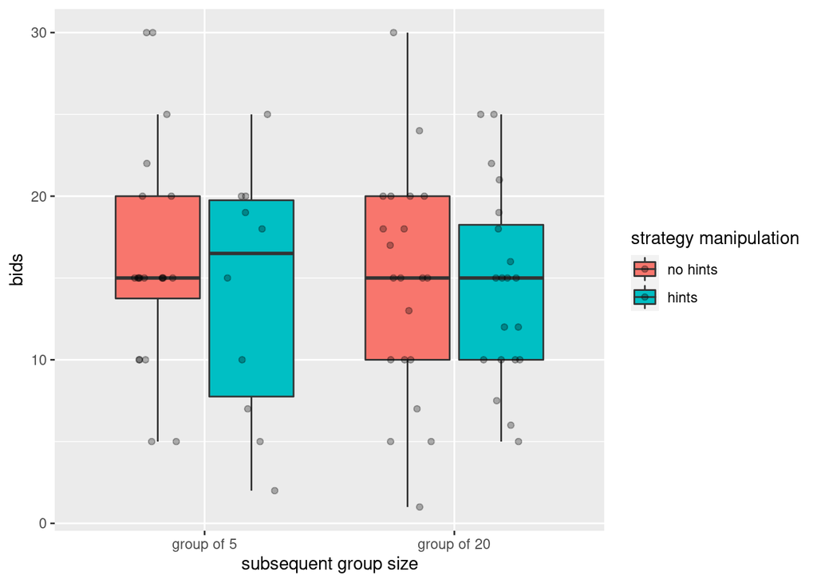

# 4 (10 marks)

**In general, what do boxplots show us? Do boxplots represent robust statistical measures? In this case, what do the boxplots show us about the bidding behavior across treatments?**

# 5 (10 marks)

**Create barcharts for the beliefs about winning the mug (variable prob), faceting the data by variables `strategy` and `size`. Hint: if using R, use functions geom_bar and facet_grid.**

# 6 (10 marks)

**In general, what do barcharts tell us? Specifically in this case, what do the barcharts tell us about beliefs of winning the mug with regards to the treatments?**

# 7 (10 marks)

**Create boxplots for clarity of instructions, partitioning the data by the variables `strategy` and `size`.**

# 8 (10 marks)

**Create boxplots for the asks, partitioning the data by the variables `strategy` and `size`.**

# 9 (10 marks)

# 10 (10 marks)

**Create boxplots for the endowment effect (ask-bid), partitioning the data by the variables `strategy` and `size`.**

# 11 (10 marks)